# Supercomputing Primer Day 2

TU/e Supercomputing Center

November 2025

## Welcome! (& intro)

## `whoami` Instructors

- Gérson Fernandes
  - Aerospace engineer. Now simulations engineer @supercomputing center.
  - Amateur car mechanic.
- Alain van Hoof
  - Seasoned systems administrator. Manager of TU/e’s Umbrella Cluster.
  - Ice skating prodigy.

## Motivation & goal

### Day 2

- ssh (inc. best practices)
- Setting up git & github
- Basics of git

## Requirements:

### A SURF Cua account

https://portal.cua.surf.nl/

( https://edu.nl/3emeq )

## Requirements:

### A terminal on Snellius, the National Super Computer

https://ondemand.snellius.surf.nl

( https://edu.nl/ed6c3 )

## Requirements:

### Basic terminal (bash) knowledge

## SSH

### Secure Shell

## SSH

For using an HPC via the command line (CLI), from for example your laptop

Access to online Cloud services like github.com.

## Why SSH

- Verify the Identity of remote systems
- Verify the Identity of the user by the remote system
- Encrypt network traffic
- Password less login

### Asymmetric Encryption

## public key

- Used for encryption that only private key can decrypt
- Can be given (published) to everyone.

## private key

- Remains (only) with the user
  - The possession of this key is proof of the user’s identity
- Used to generate public key.
- Used to decrypt what was encrypted with the public key
- Password Protected! (not SHOULD, MUST)

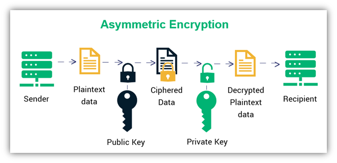

## Generating a key pair (CLI)

ssh-keygen : generate uniq Pub/Priv Key

ends up in

```bash
$HOME/.ssh/
```

## Using your key (CLI)

ssh-copy-id (Linux/Mac): place public key on the correct place on remote system

On remote system key is automaticaly added to:

```bash
$HOME/.ssh/authorized_keys
```

Examples (Linux)

```bash
ssh-copy-id <username>@snellius.surf.nl
ssh-copy-id <username>@hpc.tue.nl
```

Then

```bash
ssh <username>@snellius.surf.nl
ssh <username>@hpc.tue.nl
```

No longer a password asked (but maybe for your private key)

Loading your private key into memory

```bash
ssh-agent bash
ssh-add
```

The password for your private keys is asked, but after that the loaded key is used,  
as long as your session lasts

scp : copy a file to a remote system using SSH

```bash
scp .ssh/id_ed25519.pub <username>@hpc.tue.nl:.ssh/authorized_keys
```

## Generating a key pair walk trough

https://supercomputing.tue.nl/documentation/steps/access/ssh/ ( https://edu.nl/p4vtc )

Run `ssh-keygen -t` followed by the key type and an optional comment. This comment is included in the `.pub` file that’s created. You may want to use an email address for the comment.

For example, for ED25519 (Edwards-curve Digital Signature Algorithm)

```bash
ssh-keygen -t ed25519 -C "<comment>"
```

Press `Enter`. Output similar to the following is displayed:

```bash
Generating public/private ed25519 key pair.
Enter file in which to save the key ($HOME/.ssh/id_ed25519):
```

Specify a passphrase:

```bash
Enter passphrase (empty for no passphrase):
Enter same passphrase again:
```

A confirmation is displayed, including information about where your files are stored.

## Creating $HOME/.ssh/authorized_keys

```bash
ssh curxxxx@snellius.surf.nl # Password curxxxx?
```

```bash
cd .ssh
cp id_ed25519.pub authorized_keys
```

```bash
exit
ssh curxxxx@snellius.surf.nl # Password private key?
```

## We still need a password!

```bash
exit
ssh-agent bash
ssh-add
```

### And now we don’t:

```bash
ssh curxxxx@snellius.surf.nl
exit
```

```bash
cat id_ed25519.pub
cd ..
```

## Github Account

got to github.com

Create (Sign up) an account (if you don’t have one)

## Git

Distributed Version Control, successor to BitKeeper, SubVersion (SVN), CVS, SCCS, RCS

Created by: **Linus Trovalds**

Yes! that person who wrote and is still involved in, the **Linux Kernel**

## 10 Days!

Torvalds famously wrote Git in just 10 days after Linux kernel developers lost access to their proprietary tool, BitKeeper, due to licensing disagreements

[figure not shown]

## Uploading public key -> github

To use SSH with Github, copy your public! key to your Github account.

1. Sign in to Github.
2. On the top right, select the avatar.
3. Select **Settings**.
4. On the left sidebar, select **SSH and GPG Keys**.
5. Select **new SSH key**.
6. In the **Title** box, type a description.
7. For **Key type** use the default, `Authentication`.
8. In the **Key** box, paste the contents of your public key.
9. Select **Add SSH key**.

Copy the contents of your public key file. You can do this manually or use a script. For example, to copy an ED25519 key to the clipboard:

macOS

```bash
tr -d '\n' < ~/.ssh/id_ed25519.pub | pbcopy
```

Linux (requires the `xclip` package)

```bash
xclip -sel clip < ~/.ssh/id_ed25519.pub
```

Git Bash and PowerShell on Windows

```bash
cat ~/.ssh/id_ed25519.pub | clip
```

Replace `id_ed25519.pub` with your filename. For example, use `id_rsa.pub` for RSA.

## Check

Verify that your SSH key was added correctly.

To ensure you’re connecting to the correct server, check the server’s SSH host keys fingerprint.

For github.com, see the SSH host keys fingerprints at

https://docs.github.com/en/authentication/keeping-your-account-and-data-secure/githubs-ssh-key-fingerprints

( https://edu.nl/dqbqd )

Open a terminal and run these commands:

```bash
ssh-add -L
```

if you key is not visible:

```bash
ssh-agent bash
ssh-add
```

Now Check

```bash
ssh -T git@github.com
```

If this is the first time you connect, you should verify the authenticity of the github host. If you see a message like:

```bash
The authenticity of host 'github.com (140.82.121.3)' can't be established.
ED25519 key fingerprint is SHA256:+DiY3wvvV6TuJJhbpZisF/zLDA0zPMSvHdkr4UvCOqU.
This key is not known by any other names.
Are you sure you want to continue connecting (yes/no/[fingerprint])?
```

Type `yes` (not just y) and press `Enter`.

Run the

```bash
ssh -T git@github.com
```

command again. You should receive a

```bash
Hi `@username`! You've successfully authenticated, but GitHub does not provide shell access.
```

message.

If the welcome message doesn’t appear, you can troubleshoot by running `ssh` in verbose mode:

```bash
ssh -Tvvv git@github.com
```

## Why version control

## HPC & git

- `git` is used across the computing industry for different reasons
- We are introducing it here because often researchers work on at least 2 systems:
  - Their own laptop
  - The remote HPC cluster

## HPC & git

- Often users do not keep track of what they changed
- Nightmare scenarios can be avoided:
  - “Which version of my code did I actually run? The one with or without the bug?”
  - Why am I getting different results? Did I change my input file?”
  - “My computer crashed and I lost my code”

## We suggest that `git` gives you one way to overcome the scenarios above

- Of course, not a magical solution
- Backups are still needed

## Additional benefits:

- Easier collaboration with other researchers
- Optionally, you can share your code
- Works for any text file (code, LaTeX, markdown etc.)

## Limitations:

- Not ideal for non-text files (.png, .docx, .pptx, binary files)
- Not ideal for large files

## git vs. github/gitlab

- `git` is a free and open source software https://git-scm.com/about/free-and-open-source
- Can be installed on your laptop
- Just using git is sufficient if all you want is to work on one machine by yourself
- github/gitlab/etc. are services that give users cloud/remote functionality based on git
- All TU/e users have access to `gitlab.tue.nl` for private repositories and to `gitub.com` where enterprise features can be requested.

## Configuring git

Git commits carry metadata about the author. Two things you will always need to define somewhere are:

```bash
$ git config --global user.name "Your Name"
$ git config --global user.email yourname@example.com
```

Git sometimes needs to start a text editor for you to enter messages (unless you create commits from inside an editor or on the web). This may have already been set to something but if not `nano` is usually a safe choice:

```bash
$ git config --global core.editor nano
```

## Create and clone a repo

To start, create a sample project in github.

1. In github, go to the Dashboard by clicking the github logo in the top left
2. In the left sidebar, at the top, select the **new** button
3. Select the **owner** (you) and type a **Repository name**
4. At **Initialize this repository with:** Select : **Add a README file**
5. Select **Create repository**.

## Clone your repo

Now you can clone the repository in your project. **Cloning** a repo means you’re creating a copy on your computer, or wherever you want to store and work with the files.

Select your new Repository and make sure select the **Code** tab, then copy the SSH URL from the dropdown button **Clone**

Open a terminal and go to the directory where you want to clone the files.

Run the command `git clone` with a pasted URL:

```bash
git clone git@github.com/username/my-sample-project.git
```

Go to the directory:

```bash
cd my-sample-project
```

By default, you’ve cloned the default branch for the repository. Usually this branch is `main`. To be sure, get the name of the default branch:

```bash
git branch
```